# Developping_Marbles

Simon

16/01/2019

# Agenda

TODO: Posterior predictives. * I added a first model * Fit a model not on the estimates but on the ditibutions as seen by the participants. How does this change estimates for rho? They will go up. * no age correlations in any of the Parameters, which is wierd, I probably did not do it right * We are still waiting for 16 participants, But maybe we can already start thinking about this a little more * Miniconference.

# Marble Data

In this document we have a look at the Data from the Marble Task. We are supposed to have 50 participants pre, 50 post and 50 adolescents who performed a social and solo version of the experiment. They were asked to decide between safe and sure gamble options in order to recieve bonus points. Sometimes the outcome probabilites were described to them as marbles in a jar. On other occasions the outcome probabilites had to be inferred by the participants. This was possible through seeing samples from an urn. Participans always saw 9 pieces of information. Then we asked them for an estimate about the proportion of marbles in that urn. Subsequently we asked how sure there are about this estimate. Only then they made a choice. In the Social trials we showed participants the choices of another subject who completed a similar task before [here is the paper](http://www.tandfonline.com/doi/full/10.1080/87565641.2016.1158265). This made it possible to choose an adviosr with a ralistic choice function. Advisors were selected to make risky choices 20% more than the subject before. The raw data was pretty messy, because it was collected on two servers and every trial has an own column but doesnt save all information. I used this script to tidy up.

# look at the subjects.

For some reason this Histogram bins the first subjects together but this is the numebr of trials competed by every subject. 144 as it should be (4*36). But generally, this looks satisfying and as if i did not screw anything up when coding, saving and making the SQL Data Tidy.

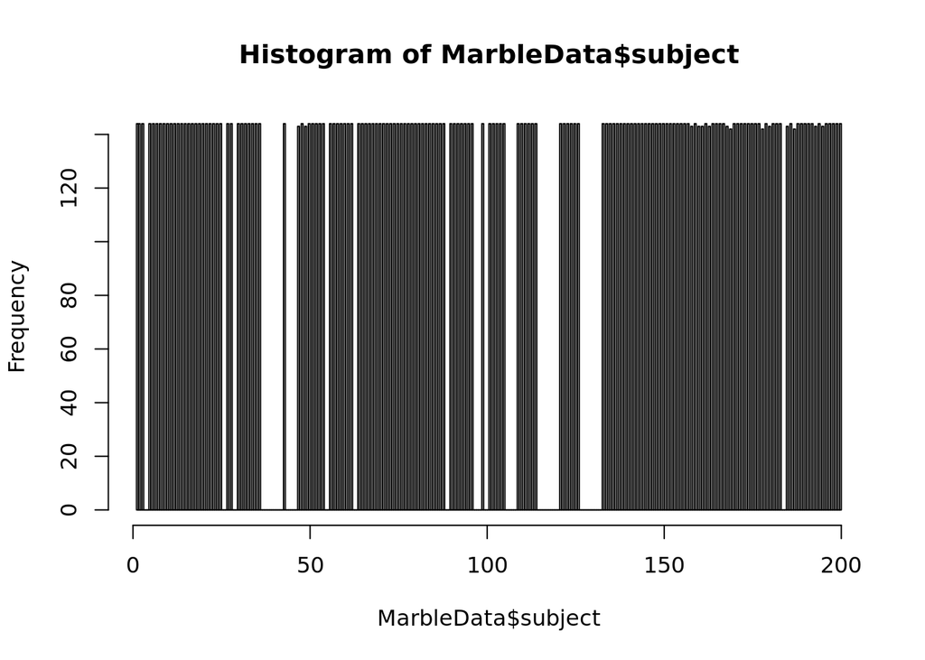

```r
MarbleData<-read.csv("A_RawData/TidyMarbleNew.csv")
hist(MarbleData$subject,breaks=length(unique(MarbleData$subject))*4)
```

# read in covariates

Here In the beginning i read in the participants intelligence scores but do not do anything with it actually.

And here i reformat the stuff i need.

```r
#MarbleData$PubertyStage=as.factor(MarbleData$PubertyStage)
MarbleData$DFE1DFD0=as.factor(MarbleData$DFE1DFD0)
MarbleData$Social1Ind0=as.factor(MarbleData$Social1Ind0)
MarbleData$PercentBlueEstimate=round(as.numeric(MarbleData$PercentBlueEstimate))
MarbleData$PercentBlueShownRel=round(as.numeric(MarbleData$PercentBlueShownRel),2)
MarbleData$PercentBlueShownRel=as.factor(as.character(MarbleData$PercentBlueShownRel))
MarbleData$HowSure=as.numeric(as.character(MarbleData$HowSure))
MarbleData$subject=as.numeric(as.character(MarbleData$subject))


QuestionnaireData<-read.csv("A_RawData/Questionnaire_SumScore.csv")

QuestionnaireData%>%group_by(subject)%>%mutate(
  SumPDS=(as.numeric(as.character(PDS1.x))+1)+(as.numeric(as.character(PDS2.x))+1)+(as.numeric(as.character(PDS3.x))+1)
)%>%mutate(PubertyStage=case_when(
  (SumPDS==4)~1,
  (SumPDS>=4 & SumPDS<6)~2,
  (SumPDS>=6 & SumPDS<8)~3,
  (SumPDS>=8 & SumPDS<11)~4,
  (SumPDS>=11)~5
))%>%select(PubertyStage,subject)%>%right_join(MarbleData,by = "subject")->MarbleData

MarbleData$PubertyStage=as.factor(MarbleData$PubertyStage)
MarbleData=MarbleData[!is.na(MarbleData$PubertyStage),]
```

# Lets have a first Look at the Data

How many subjects are there in each group?

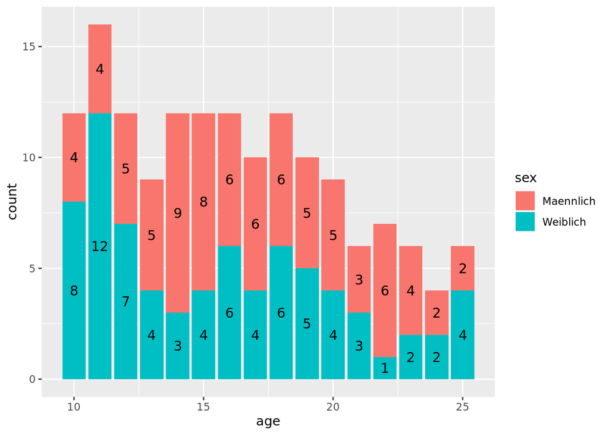

```r
MarbleData%>%select(age,sex,subject)%>%unique()%>%ggplot(aes(x=age,fill=sex))+geom_bar()+geom_text(stat='count', aes(label=..count..), position = position_stack(vjust = 0.5),size=4)
```

## Risky Choice

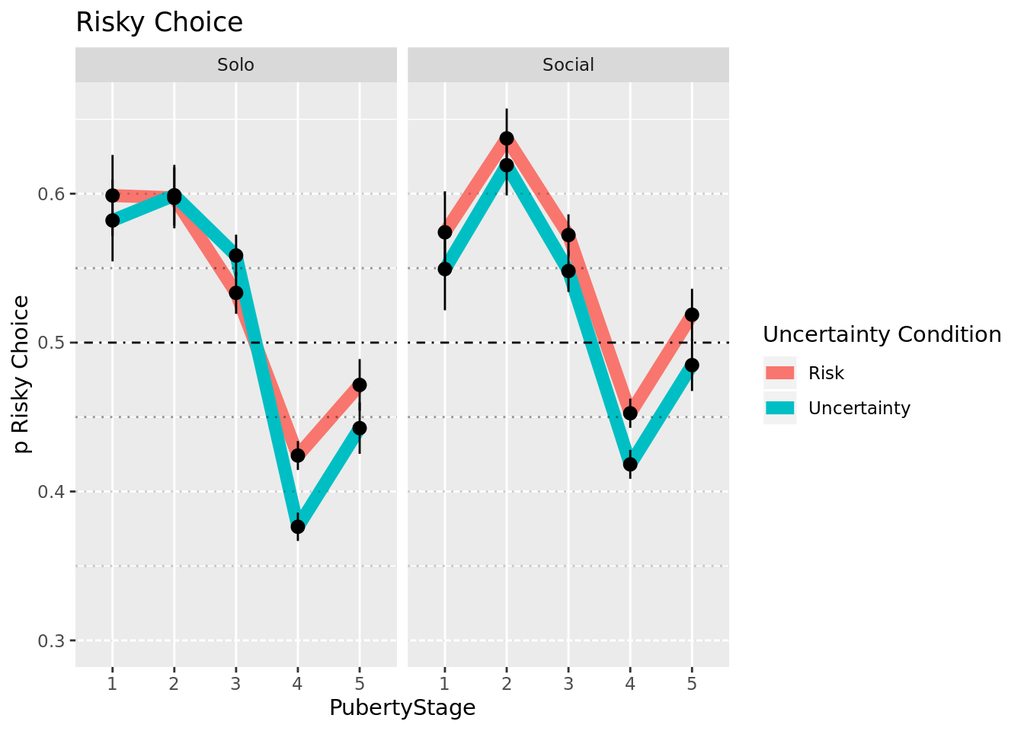

# Description Expierence Gap

IS REVERSED! By using representative samples, we squised the description expiereince gap.

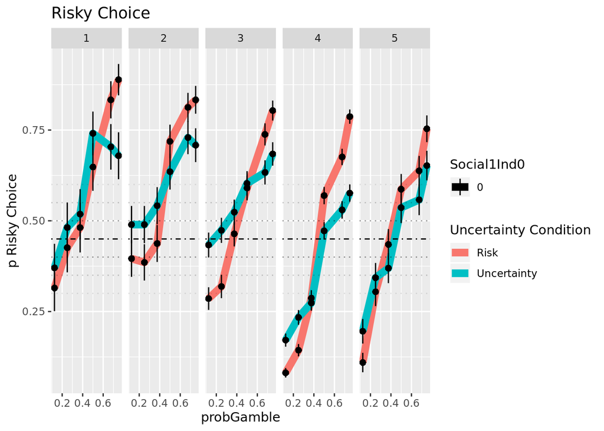

```r
MarbleData%>%filter(Social1Ind0==0)%>%ggplot(aes(y=ChooseRisk,x=probGamble,group=DFE1DFD0,shape=Social1Ind0,linetype=Social1Ind0))+stat_summary(mapping=aes(color=DFE1DFD0,linetype=Social1Ind0),geom="line",fun.y = mean, size=3)+
 stat_summary(geom="pointrange",fun.y=mean,fun.ymin =function(x) mean(x)-(sd(x)/sqrt(length(x))),fun.ymax=function(x) mean(x)+(sd(x)/sqrt(length(x))))+
  #scale_x_discrete(name="PubertyStage",breaks=c(0,1,2),labels=c("Kids","Adolescents","Adults"))+
  scale_color_discrete(name="Uncertainty Condition",breaks=c(0,1),labels=c("Risk","Uncertainty"))+
  geom_hline(mapping=aes(yintercept=0.45),linetype="dotdash")+
  geom_hline(mapping=aes(yintercept=0.5),linetype="dotted",alpha=0.4)+
  geom_hline(mapping=aes(yintercept=0.4),linetype="dotted",alpha=0.4)+
  geom_hline(mapping=aes(yintercept=0.55),linetype="dotted",alpha=0.2)+
  geom_hline(mapping=aes(yintercept=0.35),linetype="dotted",alpha=0.2)+
  geom_hline(mapping=aes(yintercept=0.6),linetype="dotted",alpha=0.1)+
  geom_hline(mapping=aes(yintercept=0.3),linetype="dotted",alpha=0.1)+
  facet_grid(.~PubertyStage
             #labeller = labeller(Social1Ind0 = labels)
             #  OtherChoseRisk=labels2
  )+
  #coord_cartesian(ylim=c(0.3,0.6))+
  scale_y_continuous(name="p Risky Choice")+
  ggtitle("Risky Choice")
```

# Within subject change.

We have a within subject design. So the appropriate thing to do here is to look at within subject change between solo and social but also risk and uncertainty. When you´re Uncertain what to do you should shift your behavior more when you observe social information. In the Uncertain condition there seems to be a linear development from shifting less towards more. In Risky Choice, adolescents seem to be most stubborn.

```
## Automatically converting the following non-factors to factors: subject
```

```
## Automatically converting the following non-factors to factors: subject
```

```
## Automatically converting the following non-factors to factors: subject
```

```
## Automatically converting the following non-factors to factors: subject
```

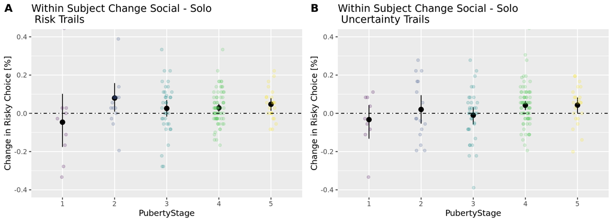

## How Good were they at Estimating?

In the Decisions from Expierience trials we asked Pariticpants about what they thing the outcome Ditribution really was. So now see if there are age differnces in estimating these distributions. For this i treat the real distributions as factors.

```
## No summary function supplied, defaulting to `mean_se()
```

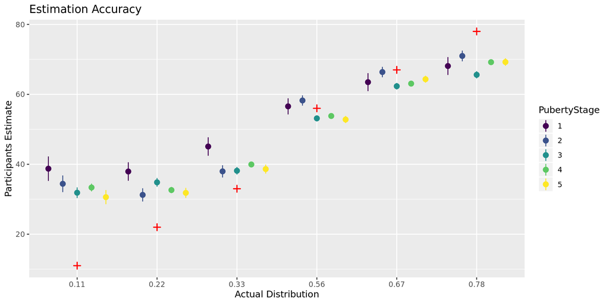

```r
MarbleData%>%filter(DFE1DFD0=="1"&PercentBlueEstimate!="NULL")%>%ggplot()+
  #stat_summary(geom="bar",fun.y = "mean",position="dodge")+
  stat_summary(aes(x=PercentBlueShownRel,y=PercentBlueEstimate,color=PubertyStage),geom="pointrange",fun.y=mean,fun.ymin =function(x) mean(x)-(sd(x)/sqrt(length(x))),fun.ymax=function(x) mean(x)+(sd(x)/sqrt(length(x))),position = position_dodge(0.9))+

  stat_summary(aes(y=as.numeric(as.character(PercentBlueShownRel))*100,x=PercentBlueShownRel),geom="pointrange",position = position_dodge(0.9),shape=3,color="red")+
  scale_shape_manual(name="Distribution as Seen by Participant")+
  scale_color_viridis_d(name="PubertyStage")+
  scale_x_discrete(name="Actual Distribution")+
  scale_y_continuous(name="Participants Estimate")+
  #coord_cartesian(ylim=c(30,70))+
  ggtitle("Estimation Accuracy")
```

```r
ggsave(filename="X_Figures/Accuracy.pdf")
```

```
## No summary function supplied, defaulting to `mean_se()
```

Turns out they were accurate and captured the trends. While estimating similarly well, Children & Adolescents tended to be overoptimistic in their estimation. This effect looks smaller with higher proportions of blue marbles. Participants also were all Optimistic for low probabilites and Pessimistic for high ones. Which is interesting because it aligns with what we have seen above and could explain the reversal of the description expierence gap here.

## Who is most Confident?

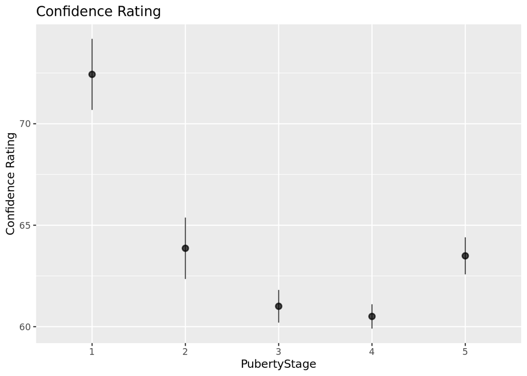

```r
MarbleData%>%filter(DFE1DFD0=="1"&PercentBlueEstimate!="NULL")%>%
  ggplot(aes(x=PubertyStage,y=HowSure,alpha=PubertyStage))+
  #stat_summary(geom="bar",fun.y="mean")+
  stat_summary(geom="pointrange",fun.y=mean,fun.ymin =function(x) mean(x)-1.96*(sd(x)/sqrt(length(x))),fun.ymax=function(x) mean(x)+1.96*(sd(x)/sqrt(length(x))),position = position_dodge(0.9),alpha=0.7)+
  #geom_jitter(aes(x=as.numeric(PubertyStage),y=HowSure))+
  scale_x_discrete(name="PubertyStage")+
  scale_y_continuous(name="Confidence Rating")+
  guides(alpha=F)+
  #coord_cartesian(ylim=c(55,65))+
  ggtitle("Confidence Rating")
```

```r
ggsave(filename="X_Figures/Confidence.pdf")
```

##### Is this substantial?

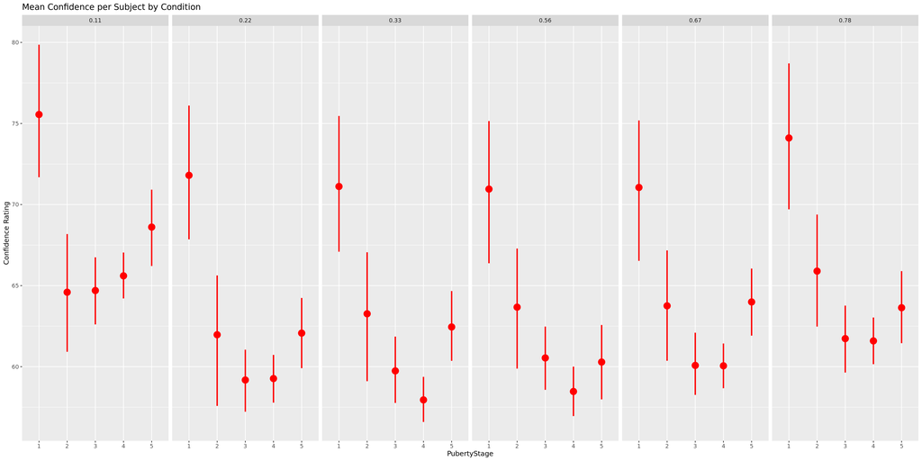

```r
MarbleData%>%filter(DFE1DFD0=="1"&PercentBlueEstimate!="NULL")%>%
  ggplot(aes(y=HowSure,x=PubertyStage,group=PubertyStage))+
  #geom_jitter(aes(color=PercentBlueShownRel),width = 0.1)+
   stat_summary(fun.data = mean_cl_boot,geom="pointrange",size=1,color="red")+
  #geom_flat_violin(position = position_nudge(x = .25, y = 0),adjust =2, trim = TRUE,alpha=0.1,fill="black")+
 # geom_pointrange(aes(x = as.numeric(PubertyStage)+0.2, y = HowSure),outlier.shape = NA, alpha = 0.3, width = .1, colour = "BLACK", nudge_x = 1, nudge_y = 2) +
  scale_color_viridis_d(name="Observed outcome Probability")+
  scale_x_discrete(name="PubertyStage")+
  #geom_hline(yintercept = 150,linetype="dotdash")+
  scale_y_continuous(name="Confidence Rating")+
  ggtitle("Mean Confidence per Subject by Condition")+facet_grid(~PercentBlueShownRel)
```

## How does the Estimation Accuracy Relate to Confidence?

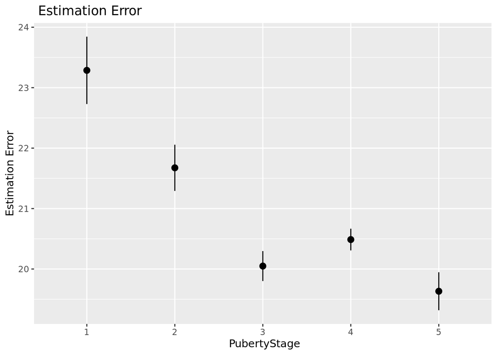

```r
labels <- c(
  "0" = "Kids",
  "1" = "Adolescents",
  "2" = "Adults"
)

MarbleData%>%filter(PercentBlueEstimate!="NULL")%>%mutate(
  Error=abs((as.numeric(PercentBlueEstimate) - as.numeric(as.character(PercentBlueShownRel))*100))
)%>%ggplot(aes(x=PubertyStage,y=as.numeric(Error)))+
  #stat_summary(geom="bar",fun.y = "mean",position="dodge")+
  #stat_smooth(method="loess")+
  stat_summary(geom="pointrange",fun.y=mean,fun.ymin =function(x) mean(x)-(sd(x)/sqrt(length(x))),fun.ymax=function(x) mean(x)+(sd(x)/sqrt(length(x))),position = position_dodge(0.9))+
  #facet_grid(.~PubertyStage,
  #           labeller = labeller(PubertyStage = labels)
  #)+
  scale_x_discrete(name=" PubertyStage")+
  scale_y_continuous(name="Estimation Error")+
  ggtitle(" Estimation Error")#+coord_cartesian(ylim=c(10,30))
```

### Inverse U?

Maybe the confidence has got more to do with the particiapnts estimate per se than with their accuracy. Is this enough to say that adolescents are more calibrated?

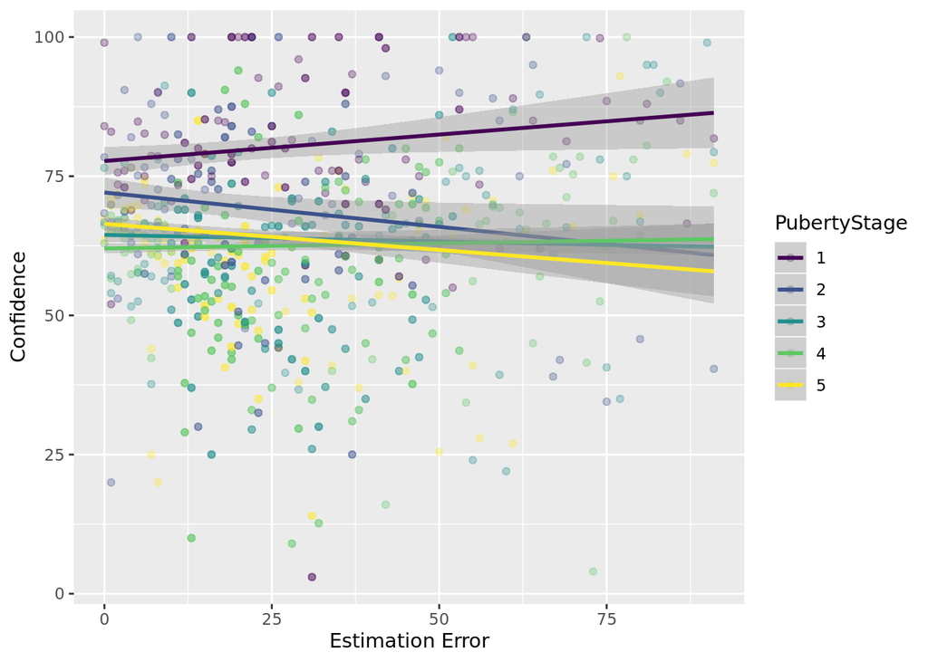

```r
labels <- c(
  "0" = "Kids",
  "1" = "Adolescents",
  "2" = "Adults"
)


MarbleData%>%filter(DFE1DFD0=="1"&PercentBlueEstimate!="NULL",HowSure!=50)%>%mutate(
  delta=abs(as.numeric(as.character(PercentBlueShownRel))*100-as.numeric(PercentBlueEstimate))
)%>%ggplot(aes(x=delta,y=(HowSure),color=PubertyStage,group=PubertyStage))+
  #geom_point()+
  stat_summary(geom="point",fun.y = "mean",position="dodge",alpha=0.3)+
  stat_smooth(method="lm")+
  scale_color_viridis_d(name="PubertyStage")+
  #stat_summary(geom="pointrange",fun.y=mean,fun.ymin =function(x) mean(x)-(sd(x)/sqrt(length(x))),fun.ymax=function(x) mean(x)+(sd(x)/sqrt(length(x))),position = position_dodge(0.9))+
  #facet_grid(.~PubertyStage,
 #            labeller = labeller(PubertyStage = labels)
 # )+
  scale_x_continuous(name="Estimation Error")+
  scale_y_continuous(name="Confidence")
```

# Everything Down here can not be more preliminary

## Models

I outsourced Modelfitting to the tardis Here i fit a model that assumes different hyperdistributions for age groups.

We can look at it indivdually later on but i think this can provide a good first look. First i need to concatanete the subject parameters. For this I need to retrieve the real Values at some point.

```r
ModelParamsFull=list()
subCount=1
for (j in 1:length(unique(MarbleData$Agegroup))){

  fitSep<-readRDS(paste0("C_ModelFits/Marbles_Model_4Age_",j,".rds"))
  Parameters<-(rstan::extract(fitSep))
  library(tidyverse)

  #Bin_Update_Data<-Bin_Update_Data[Bin_Update_Data$typeRA=="1",]# keep only The Risk trails.
  Bin_Update_Data<-MarbleData%>%arrange(Agegroup)# i order it first so i can make sure that
  PubertyStages<-unique(Bin_Update_Data$Age.bins)# for indexing my PubertyStages.

  #make it fit with my stan file.
  Bin_Update_Data<-Bin_Update_Data%>%dplyr::mutate(
    OtherChoseRisk = case_when(
      OtherChoseRisk=="NULL" ~ 2,# i dont need this but i restricted the numbers in stan between 1 and 3
      OtherChoseRisk=="1" ~ 3,# risky choices are coded as 3 in my stan code
      OtherChoseRisk=="0" ~ 1,# safe choices are coded as 1 in my stan code
      TRUE~0 # keep the rest.
    )
  )#end PeerChoice.
  #subset it to fit on only one PubertyStage.
  # now check how many participants we have.
  Bin_Update_Data$subject<-as.numeric(Bin_Update_Data$subject)
  #change colname of subject into subjID
  numSubjs<-length(unique(Bin_Update_Data$subject))#Total Number of Subs
  subjList <- unique(Bin_Update_Data$subject)######
  ageList<-Bin_Update_Data%>%group_by(subject)%>%dplyr::summarize(
    age=mean(age)
  )%>%select(age)%>%ungroup()

  ageList=as.vector(ageList$age)


  confList<-Bin_Update_Data%>%filter(HowSure!=102)%>%group_by(subject)%>%dplyr::summarise(
    Confidence=mean(HowSure)
  )
  confList=as.vector(confList$Confidence)


  datalist = list()

  for(i in 1:dim(Parameters$alpha_add)[2]){
    df=data.frame(
      alphaAdd=as.vector(Parameters$alpha_add[,i]),
    #  betaAdd=as.vector(Parameters$beta_add[,i]),
      rho=as.vector(Parameters$rho[,i]),
      tau=as.vector(Parameters$tau[,i]),
      ocusafeRisk=as.vector(Parameters$ocu_safe_Risk[,i]),
      ocusafeUncertainty=as.vector(Parameters$ocu_safe_Uncertainty[,i]),
      ocuriskRisk=as.vector(Parameters$ocu_risk_Risk[,i]),
      ocuriskUncertainty=as.vector(Parameters$ocu_risk_Uncertainty[,i]),
      subject=subjList[subCount],
      age=ageList[subCount],# Here i need to get some kind of dictionary.
      conf=confList[subCount]
    )
    subCount=subCount+1
    datalist[[i]] <- df
  }
  ModelParamsFull[[j]] <- do.call(rbind, datalist)
}
big_data<-do.call(rbind, ModelParamsFull)
```

In what follows i look at the Whole parameter Distributions.

# Individual parameters

After i collect the fits, we can actually nicely concatenate them.

```r
PosteriorMean<-big_data%>%dplyr::group_by(subject,age,conf)%>%dplyr::summarise(
  MeanAlphaAdd=mean(alphaAdd),
 # MeanBetaAdd=mean(betaAdd),
  MeanRho=mean(rho),
  meanTau=mean(tau),
  meanOCURiskR=mean(ocuriskRisk),
  meanOCURiskUnc=mean(ocuriskUncertainty),
  meanOCUSafeR=mean(ocusafeRisk),
  meanOCUSafeUnc=mean(ocusafeUncertainty)
)%>%dplyr::mutate(
  #MeanBoth=(((MeanAlphaAdd+MeanBetaAdd)/2)),
  TotalInfluenceUnc=abs(meanOCUSafeUnc+meanOCURiskUnc)/2,
  TotalInfluenceRisk=abs(meanOCUSafeR+meanOCURiskR)/2,
  #MeanBoth=(9^((MeanAlphaAdd+MeanBetaAdd)/2)),
  Group=case_when(
    age<13~"1",
    (age>12 & age <19)~"2",
    age>=19~"3"
    #TRUE
  )
)


QuestionnaireData%>%group_by(subject)%>%mutate(
  SumPDS=(as.numeric(as.character(PDS1.x))+1)+(as.numeric(as.character(PDS2.x))+1)+(as.numeric(as.character(PDS3.x))+1)
)%>%mutate(PubertyStage=case_when(
  (SumPDS==4)~1,
  (SumPDS>=4 & SumPDS<6)~2,
  (SumPDS>=6 & SumPDS<8)~3,
  (SumPDS>=8 & SumPDS<11)~4,
  (SumPDS>=11)~5
))%>%select(PubertyStage,subject)%>%right_join(PosteriorMean,by = "subject")->PosteriorMean

PosteriorMean$PubertyStage<-as.factor(PosteriorMean$PubertyStage)
PosteriorMean<-PosteriorMean[!is.na(PosteriorMean$PubertyStage),]
```

## The Learning Model

In each uncertain trial, Subjects see 9 pieces of evidence. These can be either red meaning a loss and blue meaning a win. The number of observed losses is denoted by $\beta$, the number of observed wins is denoted by $\beta$. In uncertain Trails, we assume that subjects update their beliefs about the outcome distribution in a quasi Bayesian manner.

$$p \sim B(\alpha^{p},\beta^{p})$$
We allow Failures and Sucesses to be subjectively over or underrepresented by raising them to the free parameter of p. If the
$$p$$
value is smaller than 1 this means that as comparaed to bayes optimal; subjects put lower weight on the sequentially presented information.

## The Value Model

The Utility model is an expected utility model. Here we use the probability estimate which we either obtained by sampling or is described to the participant and multiply it with the subjective utility of the option. Participants could choose between a safe option which always had the Value of 5 an A risky option which can be computed as the probability of occurance times the utility.

$$EU_{solo}=p*V^\rho$$
##Social Influence

$$EU_{Social_{safe}}=EU_{solo}+\psi_{safe} \;\;\;\; \forall Advice = Safe \\
EU_{Social_{risk}}=EU_{solo}+\psi_{Risk} \;\;\;\; \forall Advice = Risky$$

## The Choice Model

The choice model takes the negative difference of these utilites $\Delta Ut$ and translates it into a choice probability by the sigmoid transformation which scales the difference between utils up and down.

$$p_{ChooseRisk}=\frac{1}{1+e^{- (EU_{safe}-EU_{risk})*\tau}}$$

# Parameter Estimates

# Learning Scaling: p

A lot of values are close to 0. Maybe we should talk about the boundaries for this parameter. Even if the exponent is negative, it will only approximate 0, but never get negative in itself so mathematically it would still make sense but we would allow subjects to be EVEN MORE UNCERTAIN. I mean, thats reasonable?

```r
library(lme4)
```

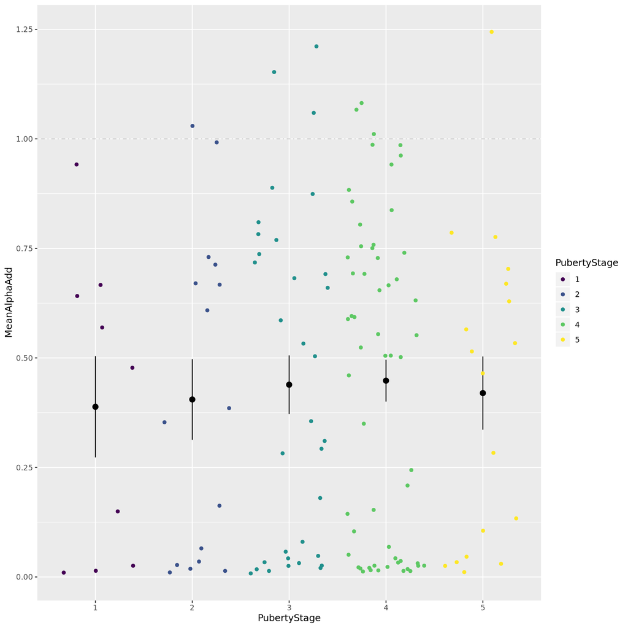

```r
#lm(MeanAlphaAdd~age,data=PosteriorMean)

ggplot(PosteriorMean,aes(x=PubertyStage,y=MeanAlphaAdd))+
  stat_summary(fun.data = "mean_se")+scale_x_discrete(name="PubertyStage")+  geom_jitter(aes(color=PubertyStage))+
  scale_color_viridis_d(name="PubertyStage")+
  #stat_summary(fun.data = "mean_se")+scale_x_discrete(name="PubertyStage",breaks=c("1","2","3"),labels=c("Age 10-12","Age 13-18","Age >18"))+
  geom_hline(aes(yintercept=1),linetype="dotdash",alpha=0.2)->learn
print(learn)
```

```r
ggsave(file='X_Figures/Learning.pdf')
```

# Reward Sensitvity

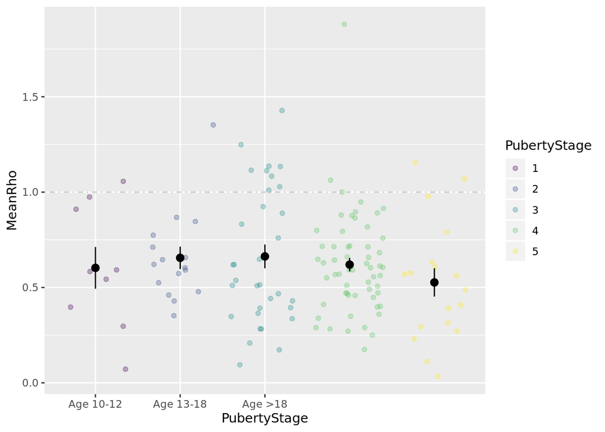

```r
#lm(meanTau~poly(age,2),data=PosteriorMean)

ggplot(PosteriorMean,aes(x=PubertyStage,y=MeanRho))+
  geom_jitter(aes(color=PubertyStage),alpha=0.3)+
  scale_color_viridis_d(name="PubertyStage")+
  stat_summary(fun.data = "mean_se")+scale_x_discrete(name="PubertyStage",breaks=c("1","2","3"),labels=c("Age 10-12","Age 13-18","Age >18"))+
  geom_hline(aes(yintercept=1),linetype="dotdash",alpha=0.2)
```

# Stochastizity?

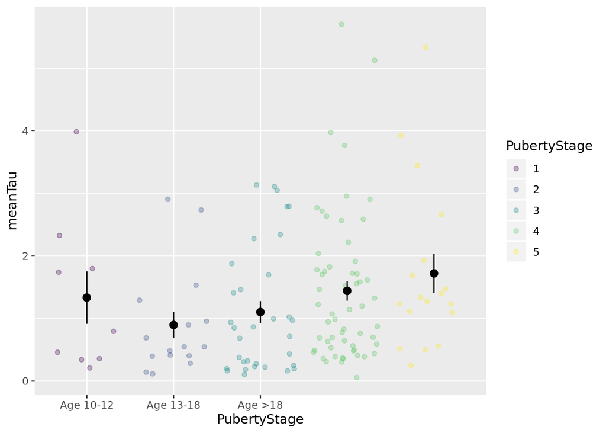

```r
#lm(meanTau~poly(age,2),data=PosteriorMean)

ggplot(PosteriorMean,aes(x=PubertyStage,y=meanTau))+
  geom_jitter(aes(color=PubertyStage),alpha=0.3)+
  scale_color_viridis_d(name="PubertyStage")+
  stat_summary(fun.data = "mean_se")+scale_x_discrete(name="PubertyStage",breaks=c("1","2","3"),labels=c("Age 10-12","Age 13-18","Age >18"))
```

# OCU Risk Decisions from Description

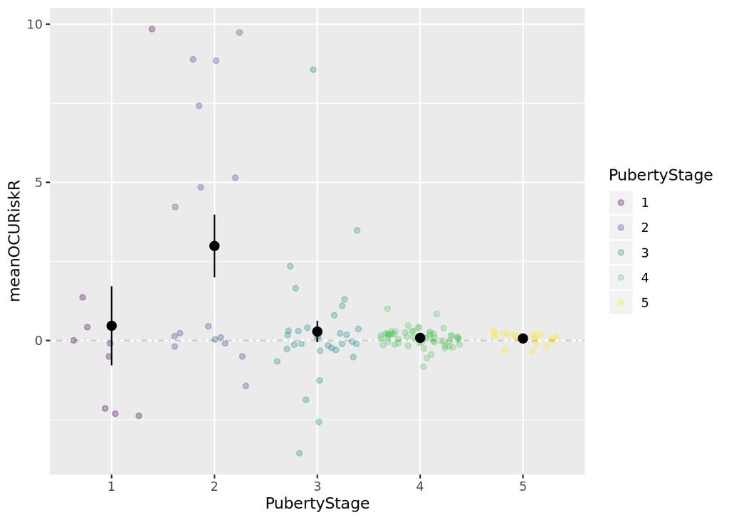

```r
#lm(meanOcuR~poly(age,2),data=PosteriorMean)

ggplot(PosteriorMean,aes(x=PubertyStage,meanOCURiskR))+
  geom_jitter(aes(color=(PubertyStage)),alpha=0.3)+
  stat_summary(fun.data = "mean_se")+
 # scale_x_continuous(name="PubertyStage",breaks=c("1","2","3"),labels=c("Age 10-12","Age 13-18","Age >18"))+
  scale_color_viridis_d(name="PubertyStage")+
  geom_smooth(method="lm")+
  geom_hline(aes(yintercept=0),linetype="dotdash",alpha=0.2)
```

# OCU Risk Decisions from Experience

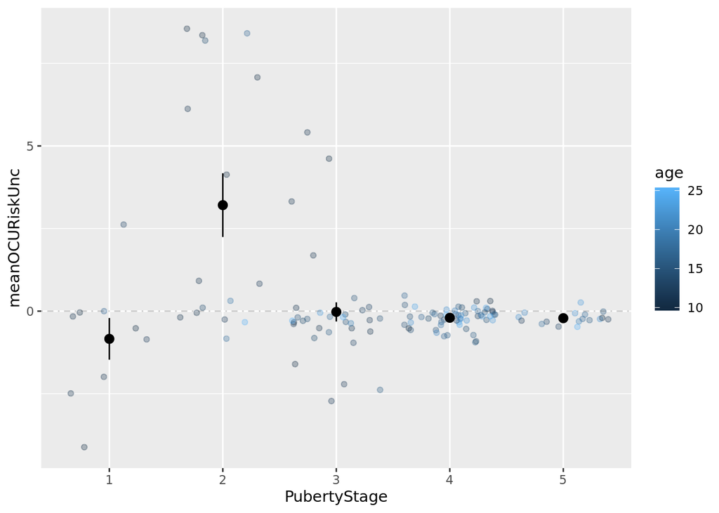

```r
#lm(meanOcuR~poly(age,2),data=PosteriorMean)
ggplot(PosteriorMean,aes(x=PubertyStage,meanOCURiskUnc))+
  geom_jitter(aes(color=age),alpha=0.3)+
  stat_summary(fun.data = "mean_se")+#scale_x_discrete(name="PubertyStage",breaks=c("1","2","3"),labels=c("Age 10-12","Age 13-18","Age >18"))+
  #scale_color_viridis_d(name="PubertyStage")+
  geom_smooth(method="lm")+geom_hline(aes(yintercept=0),linetype="dotdash",alpha=0.2)
```

# OCU Safe Decisions from Description

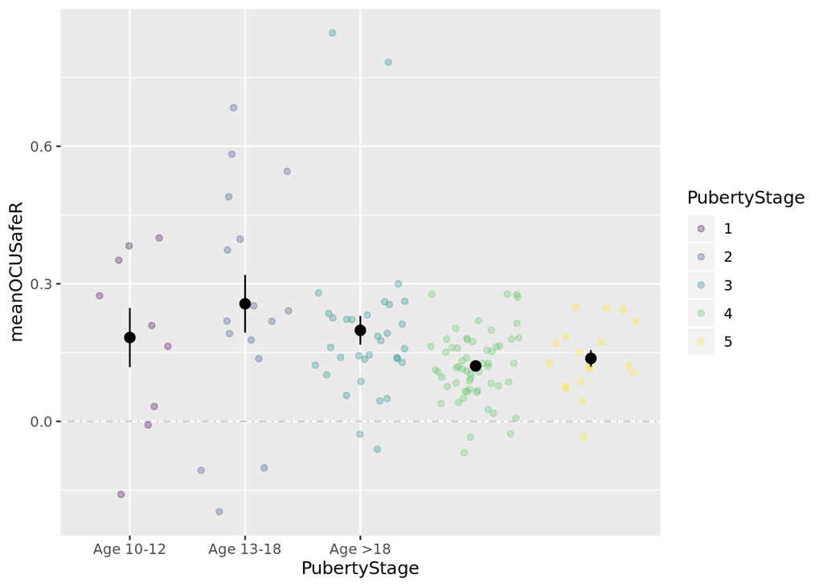

```r
#lm(meanOcuR~poly(age,2),data=PosteriorMean)

ggplot(PosteriorMean,aes(x=PubertyStage,meanOCUSafeR))+
  geom_jitter(aes(color=PubertyStage),alpha=0.3)+
  stat_summary(fun.data = "mean_se")+scale_x_discrete(name="PubertyStage",breaks=c("1","2","3"),labels=c("Age 10-12","Age 13-18","Age >18"))+
  scale_color_viridis_d(name="PubertyStage")+
  geom_smooth(method="lm")+geom_hline(aes(yintercept=0),linetype="dotdash",alpha=0.2)
```

# OCU Safe Decisions from Experience

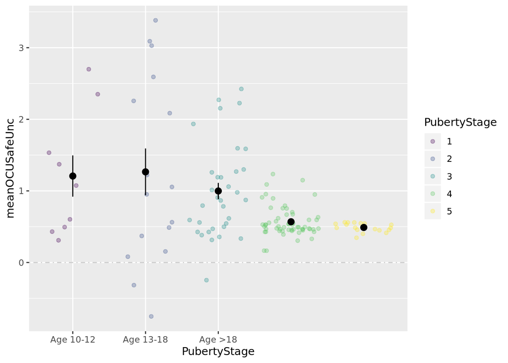

```r
#lm(meanOcuR~poly(age,2),data=PosteriorMean)

ggplot(PosteriorMean,aes(x=PubertyStage,meanOCUSafeUnc))+
  geom_jitter(aes(color=PubertyStage),alpha=0.3)+
  stat_summary(fun.data = "mean_se")+scale_x_discrete(name="PubertyStage",breaks=c("1","2","3"),labels=c("Age 10-12","Age 13-18","Age >18"))+
  scale_color_viridis_d(name="PubertyStage")+
  geom_smooth(method="lm")+geom_hline(aes(yintercept=0),linetype="dotdash",alpha=0.2)
```

# one plot

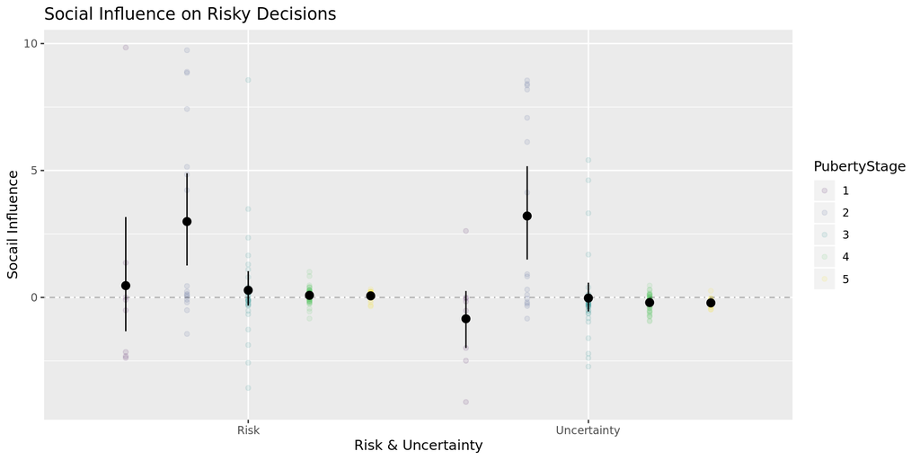

```r
PosteriorMean%>%gather(key="RiskUnc",value="measurement", meanOCURiskR,meanOCURiskUnc)%>%
  ggplot(aes(y=measurement,x=RiskUnc,color=PubertyStage,group=PubertyStage))+
  geom_point(aes(group=PubertyStage),width=0.1,position=position_dodge(0.9),alpha=0.1)+
  stat_summary(fun.data = mean_cl_boot,position=position_dodge(0.9),color="black")+
  #scale_color_viridis_d(name="PubertyStage")+
  geom_hline(yintercept = 0, linetype="dotdash", alpha=0.3)+
  ylab("Socail Influence")+
  scale_color_viridis_d(name="PubertyStage")+#,breaks=c("1","2","3"), labels=c("Pre-Adolescence","Adolescence","Post-Adoelscence"))+
  scale_x_discrete(name="Risk & Uncertainty", breaks=c("meanOCURiskR","meanOCURiskUnc"),labels=c("Risk","Uncertainty"))+
  ggtitle("Social Influence on Risky Decisions")->Risky
  plot(Risky)
```

```r
  ggsave(file='X_Figures/OCURisk.pdf')
```

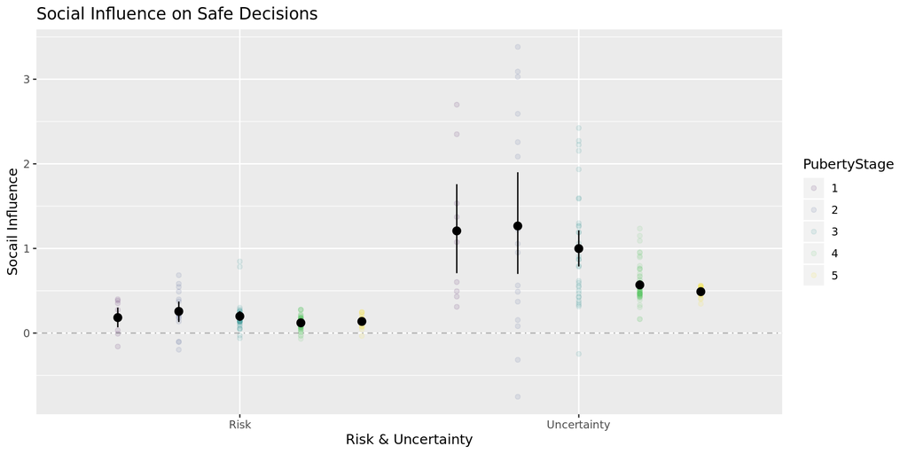

```r
PosteriorMean%>%gather(key="RiskUnc",value="measurement", meanOCUSafeR,meanOCUSafeUnc)%>%
  ggplot(aes(y=measurement,x=RiskUnc,color=PubertyStage,group=PubertyStage))+
  geom_point(aes(group=PubertyStage),width=0.1,position=position_dodge(0.9),alpha=0.1)+
  stat_summary(fun.data = mean_cl_boot,position=position_dodge(0.9),color="black")+
  geom_hline(yintercept = 0, linetype="dotdash", alpha=0.3)+
  ylab("Socail Influence")+
  scale_x_discrete(name="Risk & Uncertainty", breaks=c("meanOCUSafeR","meanOCUSafeUnc"),labels=c("Risk","Uncertainty"))+
  scale_color_viridis_d(name="PubertyStage")+#breaks=c("1","2","3"), labels=c("Pre-Adolescence","Adolescence","Post-Adoelscence"))+
  ggtitle("Social Influence on Safe Decisions")->Safe
  plot(Safe)
```

```r
  ggsave(file='X_Figures/OCUSafe.pdf')
```

```r
#cowplot::plot_grid(Risky,Safe)
```

# Social Influence and Learning?

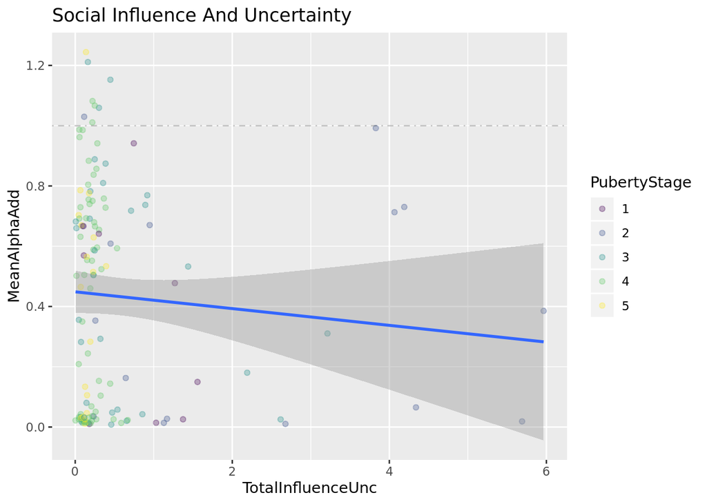

```r
#lm(meanOcuR~poly(age,2),data=PosteriorMean)

ggplot(PosteriorMean,aes(x=TotalInfluenceUnc,y = MeanAlphaAdd))+
  geom_point(aes(color=PubertyStage),alpha=0.3)+
  stat_summary(fun.data = "mean_se")+#scale_x_continuous(name="SocialInfluence Uncertainty",breaks=c("1","2","3"),labels=c("Age 10-12","Age 13-18","Age >18"))+
  scale_color_viridis_d(name="PubertyStage")+
  geom_smooth(method="lm")+geom_hline(aes(yintercept=1),linetype="dotdash",alpha=0.2)+
  ggtitle("Social Influence And Uncertainty")
```

## Who Wins

Thats the Most intersting thing of all. WHO GETS THE MOST BONUS POINTS? Lets check it.

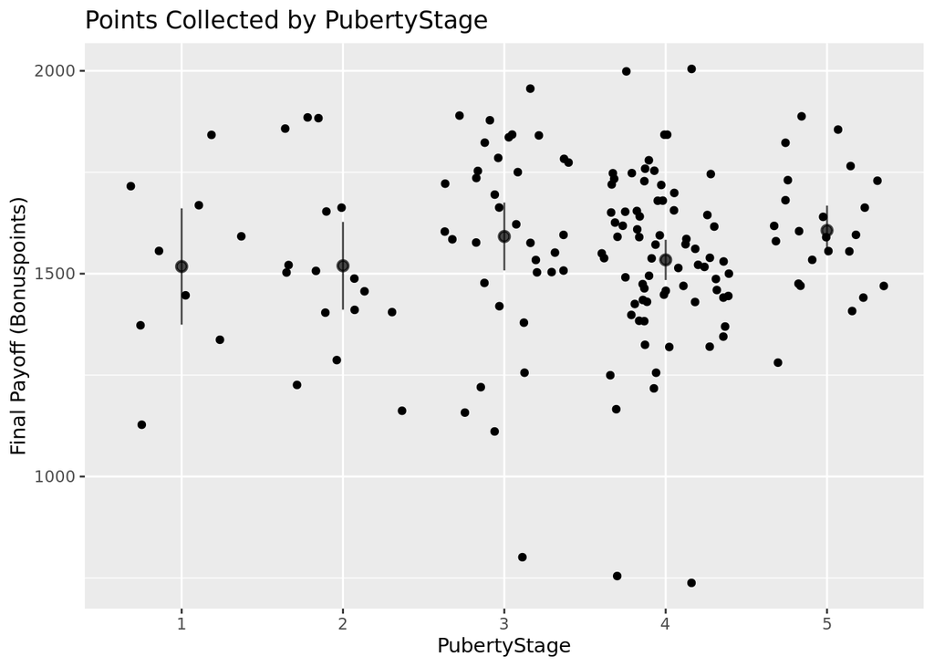

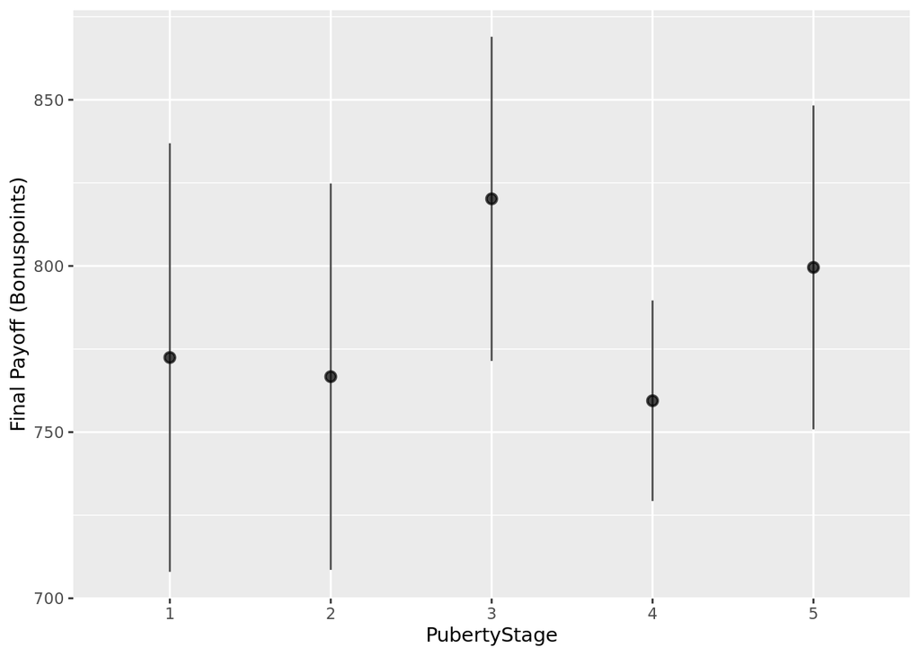

# Wierd stuff

i did some things here which i dont quite comprehend atm.

```r
# maybe
MarbleData%>%group_by(PubertyStage,DFE1DFD0,Social1Ind0)%>%dplyr::summarise(
  PercentRiskyChoice=mean(ChooseRisk),
  ci=sd(ChooseRisk)/sqrt(n())
)%>%ungroup()%>%group_by(PubertyStage,DFE1DFD0)%>%filter(Social1Ind0==0)->Solo

Solo$Diff<-Social$PercentRiskyChoice-Solo$PercentRiskyChoice

Solo%>%ggplot(aes(y=Diff,fill=DFE1DFD0,x=PubertyStage))+geom_bar(stat="identity",position = "dodge",color= "black")+
  #scale_x_discrete(name="PubertyStage",breaks=c(0,1,2),labels=c("Kids","Adolescents","Adults"))+
  geom_errorbar( mapping=aes(y=Diff, ymin=Diff-ci, ymax=Diff+ci),position="dodge")+
  scale_y_continuous(name="Mean Difference Social Solo")+
  scale_fill_discrete(name="Social Condition",breaks=c(0,1),labels=c("Risk","Uncertainty"))

# mean behavior change towards social information.

IDs[IDs$OtherChoseRisk=="NULL",]%>%group_by(subject,ID,DFE1DFD0)%>%summarize(
    meanRisk=mean(ChooseRisk)
)%>%arrange(subject,ID)->Solo

IDs[IDs$OtherChoseRisk=="1",]%>%group_by(subject,ID,DFE1DFD0)%>%summarize(
    meanRiskyRiskyOther=mean(ChooseRisk)
)%>%arrange(subject,ID)->OtherRisky


IDs[IDs$OtherChoseRisk=="0",]%>%group_by(subject,ID,DFE1DFD0)%>%summarize(
     meanRiskySafeOther=mean(ChooseRisk)
 )%>%arrange(subject,ID)->OtherSafe

One<-merge(x=Solo,y=OtherRisky, by=c("ID","subject","DFE1DFD0"),all.x = TRUE)
Two<-merge(x=One,y=OtherSafe,by=c("ID","subject","DFE1DFD0"),all.x=TRUE)

Two%>%mutate(
ChangeTowardsSafeOther=meanRiskySafeOther-meanRisk,
ChangeTowardsRiskyOther=meanRiskyRiskyOther-meanRisk
)%>%group_by(subject,DFE1DFD0)%>%summarise(
  meanChangeTowardsRisky=mean(ChangeTowardsRiskyOther,na.rm = TRUE),
  meanChangeTowardsSafe=mean(ChangeTowardsSafeOther,na.rm = TRUE)
)->meanChange


ChangeLucas=merge(x=meanChange,y=Lucas,by="subject",all.x = TRUE)%>%pivot_wider(names_from =DFE1DFD0,names_prefix = "Uncertain_",id_cols = subject,values_from =c("meanChangeTowardsRisky","meanChangeTowardsSafe"))%>%arrange(subject)

Questions_Marbles=merge(x=TidyQuestionnaireWideSums,y=ChangeLucas,by = "subject",all.x = TRUE)%>%mutate(subject=as.numeric(subject))%>%arrange(subject)
Questions_Marbles_Eyes=merge(x=Questions_Marbles,y=MindInEyes,by = "subject",all.x=TRUE)%>%mutate(subject=as.numeric(subject))
Questions_Marbles_Eyes_Numbers=merge(x=Questions_Marbles_Eyes,y=numbersResults,by = "subject",all.x=TRUE)%>%mutate(subject=as.numeric(subject))
Questions_Marbles_Eyes_Numbers_Matrix=merge(x=Questions_Marbles_Eyes_Numbers,y=cftResults,by = "subject",all.x=TRUE)%>%mutate(subject=as.numeric(subject))


damn=tibble(subject=1:200)# make it have 200 entries

Questions_Marbles_Eyes_Numbers_Matrix=merge(x=damn,y=Questions_Marbles_Eyes_Numbers_Matrix,by="subject",all.x=TRUE)%>%mutate(subject=as.numeric(subject))%>%arrange(subject)
#Questions_Marbles_Eyes_Numbers_Matrix[,]

LucasWideData=unique(dplyr::select(Questions_Marbles_Eyes_Numbers_Matrix, -c("sex.y","age.y")))

write.csv(LucasWideData,"AllThingsIMeasured.csv")
  #ggplot(aes(x=age,y=value,color=risky_safe_Change))+geom_point()+geom_smooth(method=lm)+facet_grid(.~DFE1DFD
```